# Predator extirpation and reintroduction: analysis and results

Johnson, Danet, Hänfling and Beckerman

2026-11-03

# 1 Reproducing the analysis

1. Download the repository using **Code → Download ZIP** and extract it.
2. Open `reintrov_0.4.Rmd` in RStudio. Keep `data/` and `results/` beside it.
3. Install the packages once:

```r
install.packages(c("rmarkdown", "knitr", "mgcv", "ggplot2", "patchwork",
                   "ggeffects", "ggpubr"))
```

4. Click **Knit → Knit to HTML**, or run:

```r
rmarkdown::render("reintrov_0.4.Rmd")
```

The analysis generates `reintrov_0.4.html` and saves model outputs in `results/`. A validated bootstrap checkpoint is included to reduce computation time; a full run uses 200 resamples.

# 2 Study design

We used bioenergetic food-web simulations to examine predator establishment and community responses to predator extirpation and reintroduction. Communities were simulated through three phases. First, we simulated the intact food web to establish its reference dynamics. We then removed the surviving species with the highest trophic level and simulated the community after extirpation. Finally, we reintroduced that predator at the mean biomass of surviving resident species and simulated the community after its return. Each phase comprised 2,000 model time units of burn-in followed by a 500-unit measurement window.

Community responses comprised resident species richness, total biomass, temporal biomass stability and biomass evenness. Predator responses comprised establishment, biomass and temporal biomass stability.

Responses were expressed relative to the preceding phase, except predator biomass and stability, which were compared with their intact values. Subscripts 21, 32 and 31 identify extirpated/intact, reintroduced/extirpated and reintroduced/intact ratios, respectively. Temporal stability is the inverse coefficient of variation of biomass. Variable definitions accompany the data in `data/DATA_DICTIONARY.csv`.

# 3 Simulation dataset

We generated 11,614 food-web simulations, each comprising intact, predator-extirpated and predator-reintroduced phases. We preserved the predator’s original feeding links throughout; links to prey that became extinct were inactive.

We retained 10,969 simulations for analysis after excluding 645 with unusable reintroduced/intact predator biomass ratios: 643 missing or undefined ratios and 2 infinite ratios.

# 4 Statistical models

We fitted eleven regression models: three describing predator responses and four pairs describing community responses to extirpation and reintroduction. Predator establishment was modelled with binomial regression. Predator biomass and stability, and community biomass, stability and evenness ratios, were log-transformed and fitted with Gaussian linear models. Resident-richness ratios were fitted with beta regression and a logit link. Predator biomass and stability models included established predators with finite log responses.

All models included intact-community richness, connectance, their interaction, predator diet breadth and the predator–prey mass-ratio parameter. Additional predictors represented prey persistence, community intactness, trophic height, community stability and predator establishment, as specified in the model formulas below.

| model | family | n | excluded_from_baseline |
| --- | --- | --- | --- |
| m1 | binomial logit | 10969 | 0 |
| m2 | Gaussian on log ratio | 10607 | 362 |
| m3 | Gaussian on log ratio | 10602 | 367 |
| m4 | beta logit | 10969 | 0 |
| m5 | beta logit | 10969 | 0 |
| m6 | Gaussian on log ratio | 10969 | 0 |
| m7 | Gaussian on log ratio | 10969 | 0 |
| m8 | Gaussian on log ratio | 10969 | 0 |
| m9 | Gaussian on log ratio | 10969 | 0 |
| m10 | Gaussian on log ratio | 10969 | 0 |
| m11 | Gaussian on log ratio | 10969 | 0 |

Models m1–m3 describe predator establishment, stability and biomass, respectively. Models m4/m5 describe resident richness, m6/m7 community biomass, m8/m9 community stability and m10/m11 community evenness; the first model in each pair describes extirpation and the second reintroduction. Sample sizes and exclusions are reported above; coefficients and diagnostics are reported at the end of the analysis.

# 5 Prediction scenarios

| Factor | Left | Value | Right | Value |
| --- | --- | --- | --- | --- |
| Community connectance | Strong | 0.09 | Weak | 0.06 |
| Community intactness | Intact | 1.00 | Depleted | 0.50 |
| Food-web trophic height | Short | 2.05 | Tall | 3.43 |
| Mass ratio Predator:Prey | Large | 1000.00 | Small | 10.00 |
| Predator diet breadth | Large | 12.00 | Small | 1.00 |
| Predator survival | High | 1.00 | Low | 0.00 |
| Prey intactness | Intact | 1.00 | Depleted | 0.50 |

We evaluated conditional predictions at the paired predictor values shown above, holding remaining covariates at their analysis-dataset means and intact-community richness at 50 resident species. Community-stability covariates were held at the mean of their log-transformed values. Predictors absent from a model had no effect on its predictions; predator-survival and trophic-height contrasts are consequently identical in the predator models.

For the summary figures, predicted ratios were scaled to reference values of 50 resident species, community biomass 100, predator biomass 10, stability 0.1 and evenness 0.1. These values provide a common illustrative baseline. Exponentiated predictions from log-response models represent geometric ratios.

# 6 Uncertainty estimation

We estimated 95% confidence intervals for community responses using 200 paired bootstrap resamples of simulation trajectories. Both transition models were refitted to each resample, preserving dependence when combining extirpation and reintroduction ratios. All 200 resamples completed. Predator-response intervals were calculated from model-based standard errors on the log or logit scale and back-transformed for display.

# 7 Marginal-effect plots

Conditional response curves show associations with individual predictors and their interactions, holding other covariates at their model-data means. Shaded bands indicate pointwise 95% confidence intervals. Gaussian models are shown on the log-ratio scale, with zero indicating no change; establishment and richness models are shown on the probability or proportion scale.

## 7.1 m1: Predator establishment

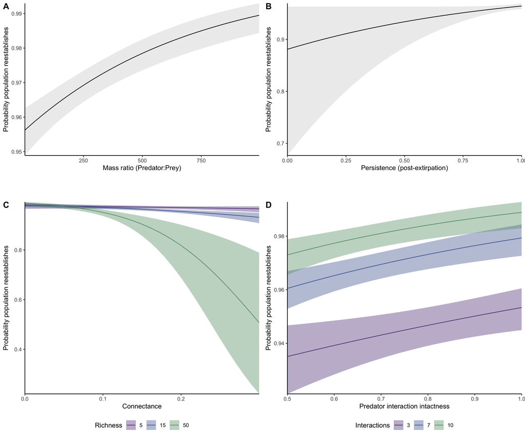

## 7.2 m2: Predator stability

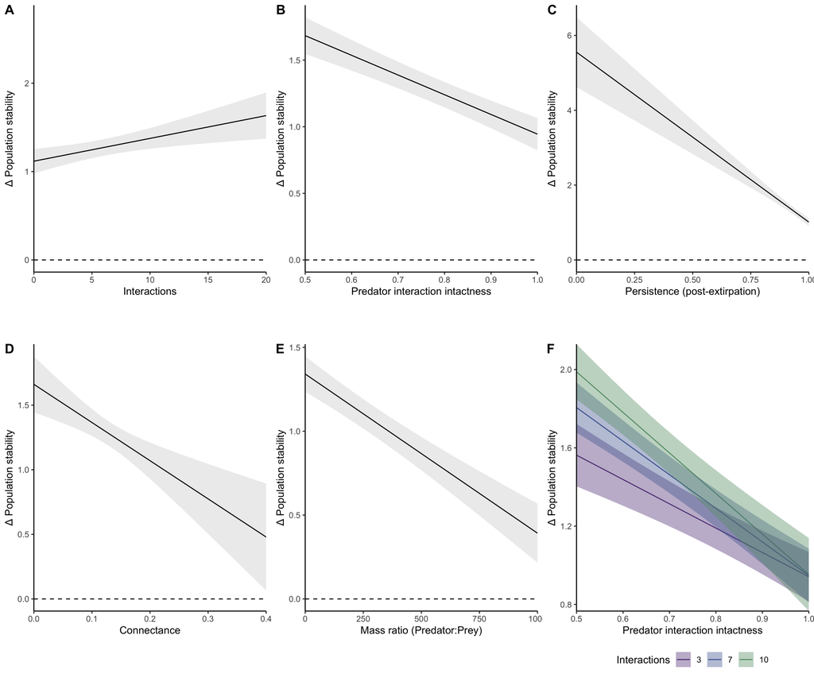

## 7.3 m3: Predator biomass

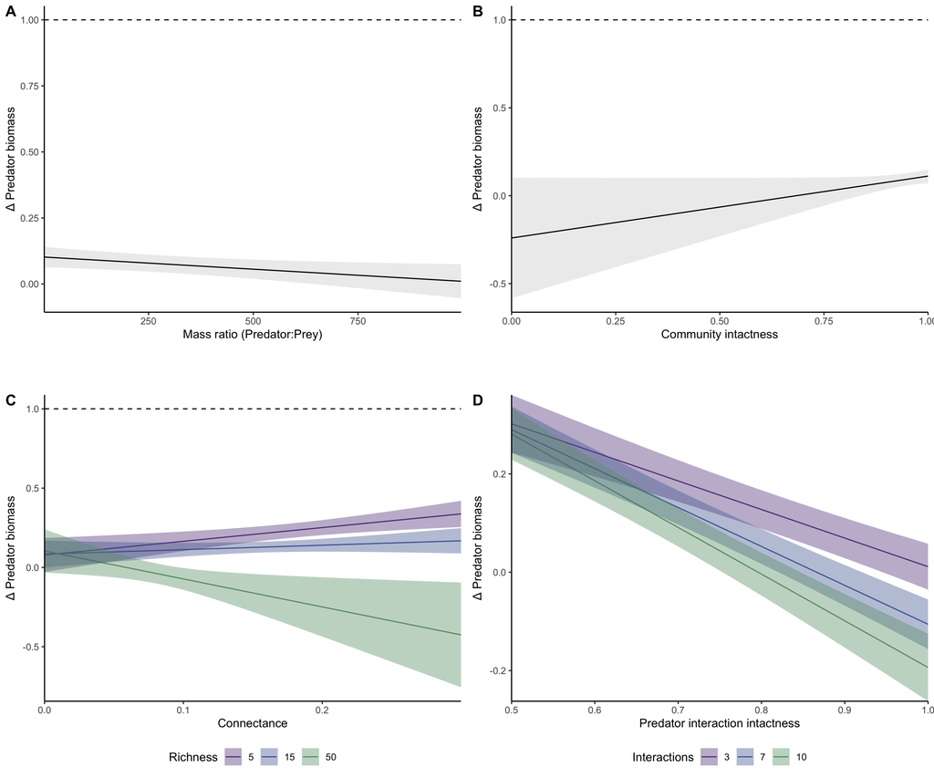

## 7.4 m4: Community richness after extirpation

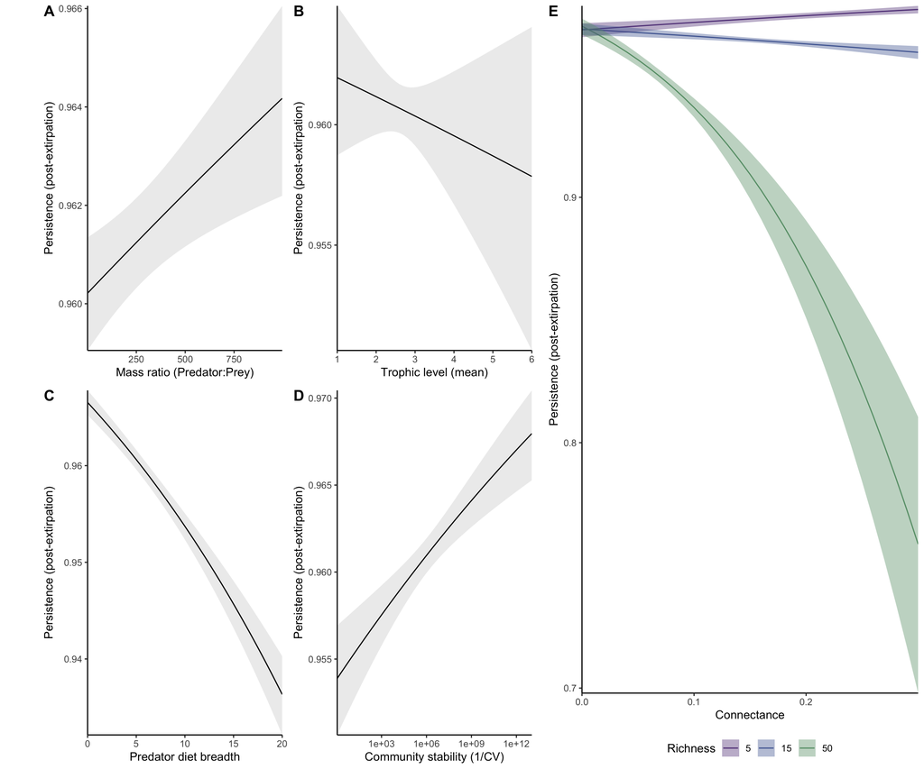

## 7.5 m5: Community richness after reintroduction

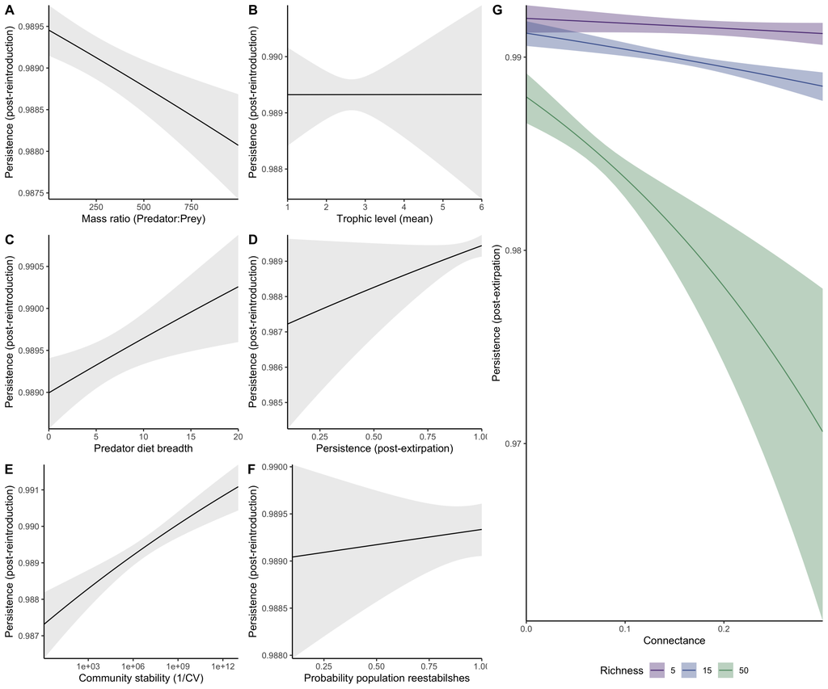

## 7.6 m6: Community biomass after extirpation

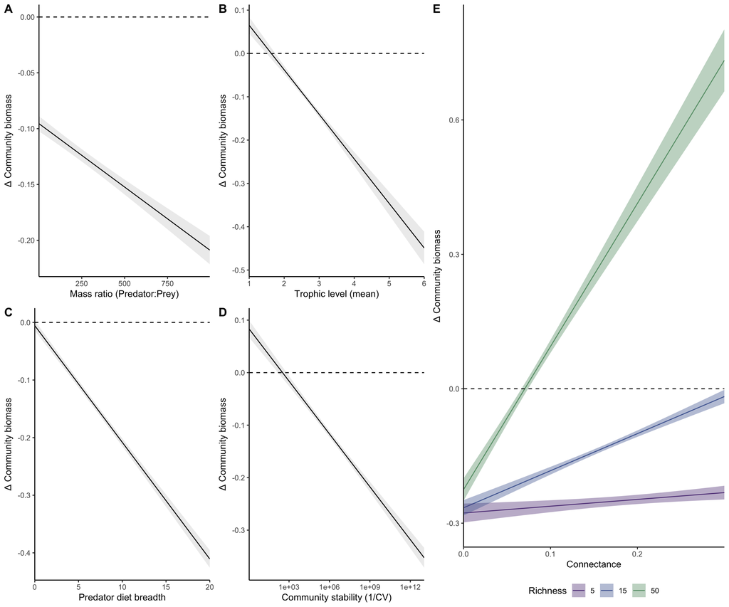

## 7.7 m7: Community biomass after reintroduction

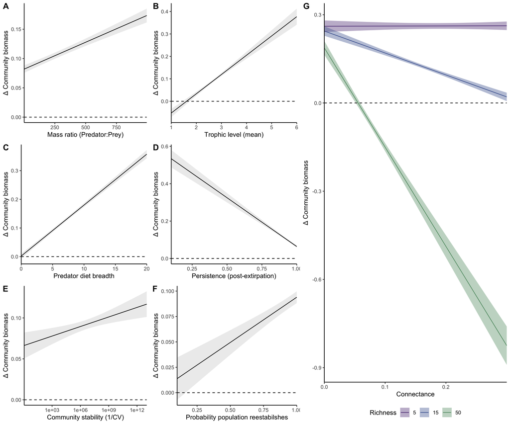

## 7.8 m8: Community stability after extirpation

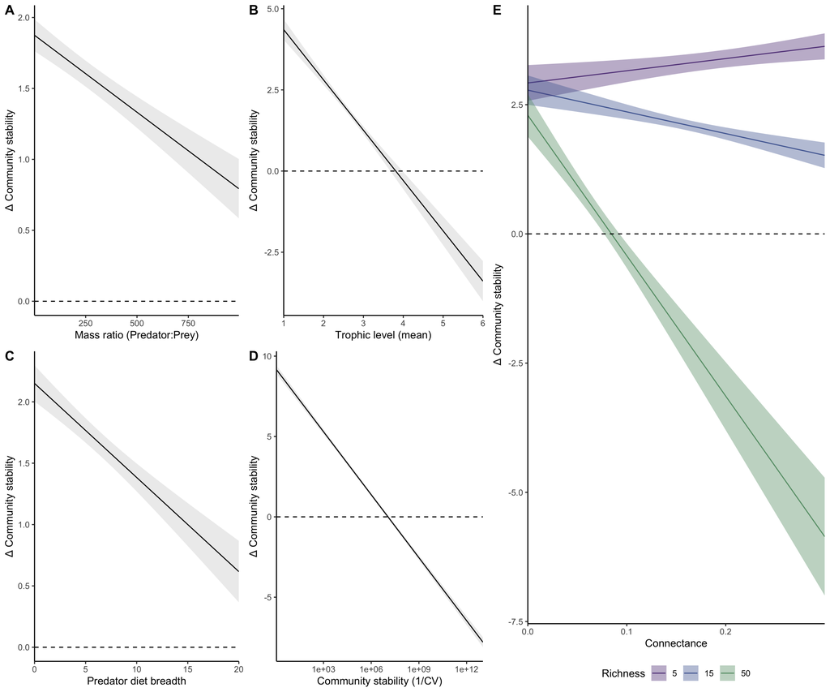

## 7.9 m9: Community stability after reintroduction

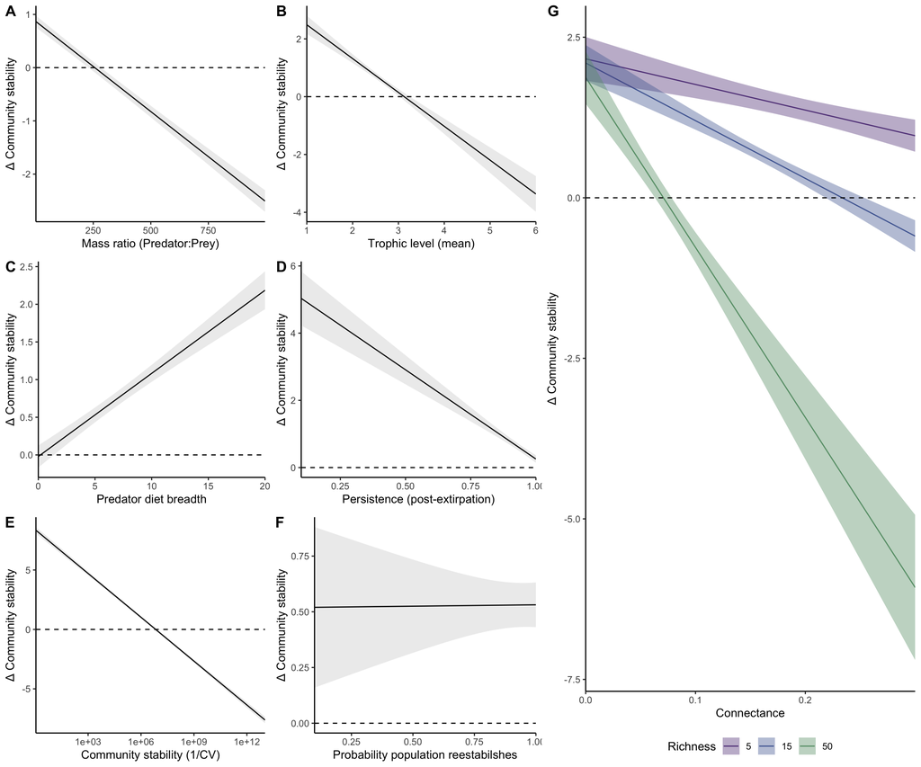

## 7.10 m10: Community evenness after extirpation

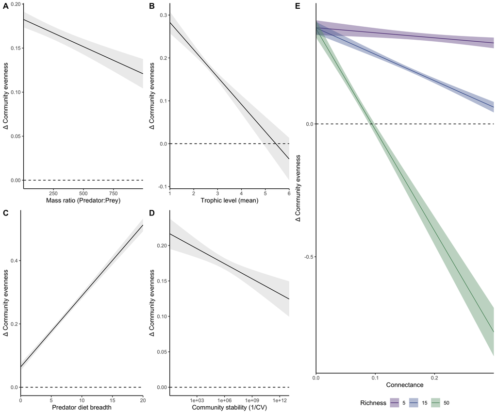

## 7.11 m11: Community evenness after reintroduction

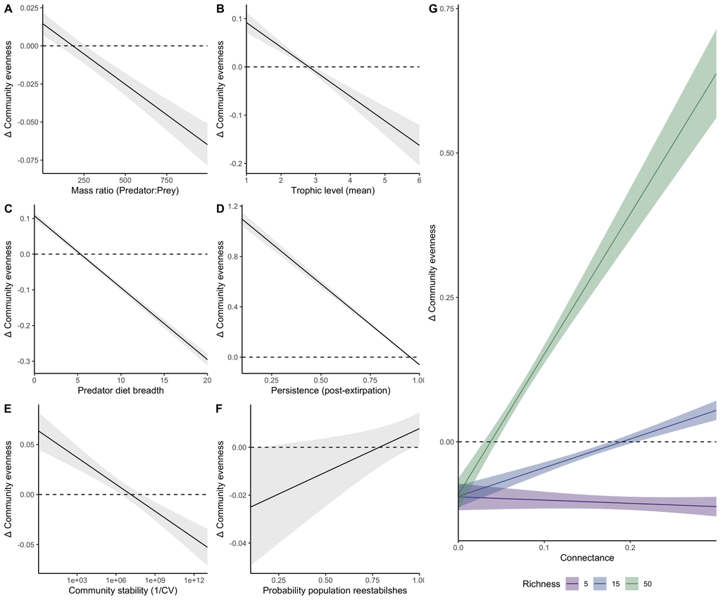

# 8 Summary of predator and community responses

## 8.1 Figure 1: community responses to extirpation

Predator extirpation reduced predicted resident richness across the four scenario contrasts. Community biomass generally increased, although the weak-connectance scenario fell below its intact reference. Stability responses varied markedly among scenarios. Evenness declined in most contrasts, while both connectance scenarios remained at or above the intact reference.

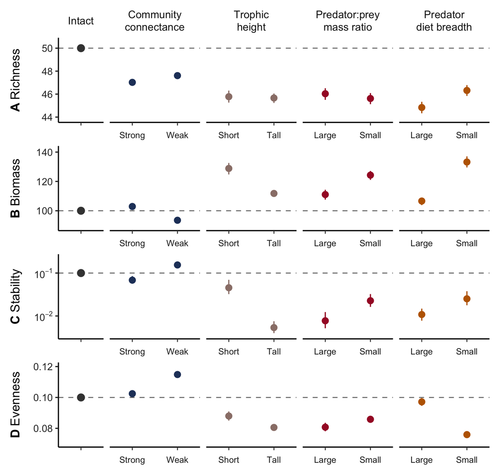

Community responses to predator extirpation. Points show conditional predictions for resident richness, community biomass, temporal stability and evenness; bars indicate 95% paired-bootstrap confidence intervals. Dashed lines mark intact reference values. Stability is plotted on a logarithmic scale.

## 8.2 Figure 2: predator responses to reintroduction

Predator establishment probabilities were generally high, but fell below 0.9 in the depleted-community and narrow-diet scenarios. Established predators usually had lower biomass than their intact reference, whereas temporal stability generally increased. At the reference covariate values, predator biomass was lower with complete recorded prey persistence than with half of prey links retained. Prey-species persistence therefore did not imply recovery of predator biomass.

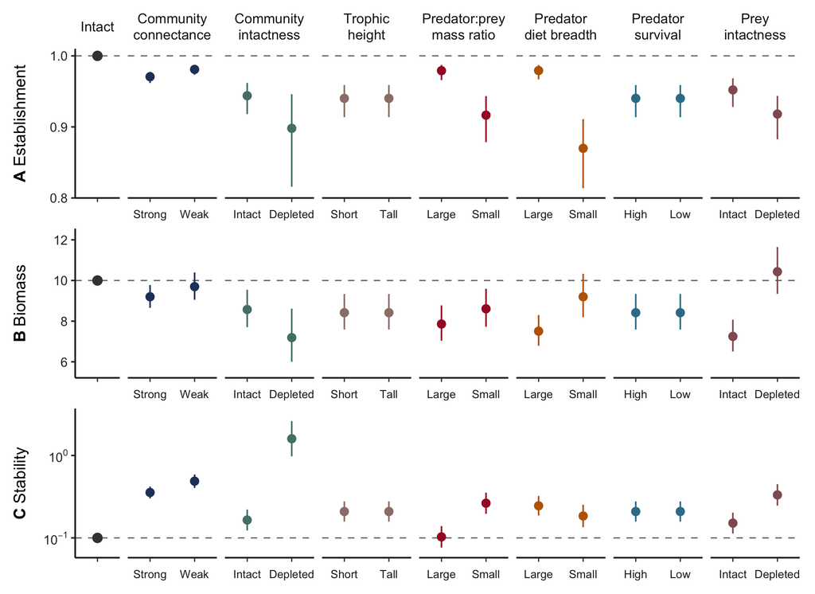

Predator responses to reintroduction. Points show establishment probability and, among established predators, biomass and temporal stability relative to intact conditions. Bars indicate pointwise 95% model-based confidence intervals. Dashed lines mark intact reference values.

## 8.3 Figure 3: community responses after reintroduction

Reintroduction produced further predicted losses of resident richness across the scenario contrasts. Biomass and stability generally declined from post-extirpation levels, with smaller changes under weak connectance and low community intactness. Evenness increased towards or beyond its intact reference, with the largest overshoot in the depleted-community scenario.

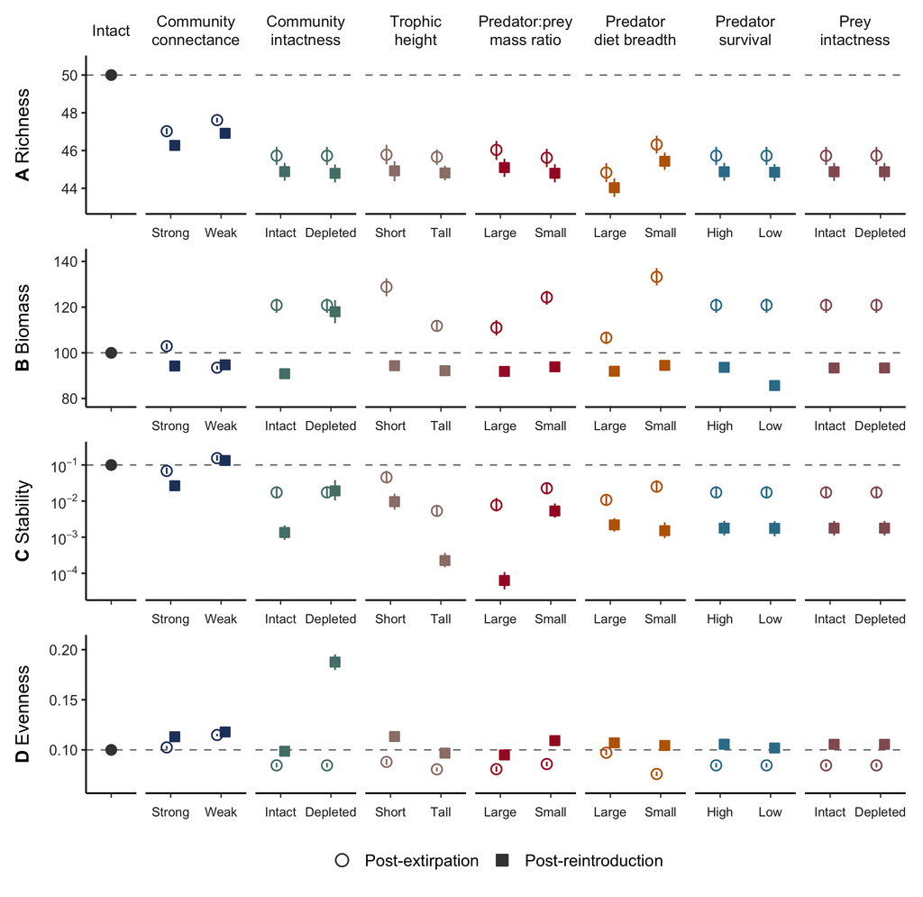

Community responses to extirpation and reintroduction. Circles show post-extirpation predictions and squares show combined predictions after reintroduction, expressed on the same intact-reference scale. Bars indicate 95% paired-bootstrap confidence intervals. Dashed lines mark intact reference values.

# 9 Model diagnostics and detailed results

| Model | n | AIC | Residual SD | Max residual | Converged |
| --- | --- | --- | --- | --- | --- |
| m1 | 10969 | 3037.1941 | 1.0172 | 17.8051 | TRUE |
| m2 | 10607 | 56950.1770 | 3.5421 | 25.5156 | TRUE |
| m3 | 10602 | 35703.6031 | 1.3021 | 11.9756 | TRUE |
| m4 | 10969 | -306890.0889 | 0.6657 | 5.1658 | TRUE |
| m5 | 10969 | -475997.5872 | 0.6530 | 8.8436 | TRUE |
| m6 | 10969 | -619.7618 | 0.2350 | 2.1044 | TRUE |
| m7 | 10969 | -1888.1941 | 0.2218 | 2.5108 | TRUE |
| m8 | 10969 | 60850.3983 | 3.8730 | 16.9453 | TRUE |
| m9 | 10969 | 60657.0233 | 3.8383 | 16.3696 | TRUE |
| m10 | 10969 | 5418.5103 | 0.3095 | 1.9087 | TRUE |
| m11 | 10969 | 1695.5238 | 0.2612 | 1.8680 | TRUE |

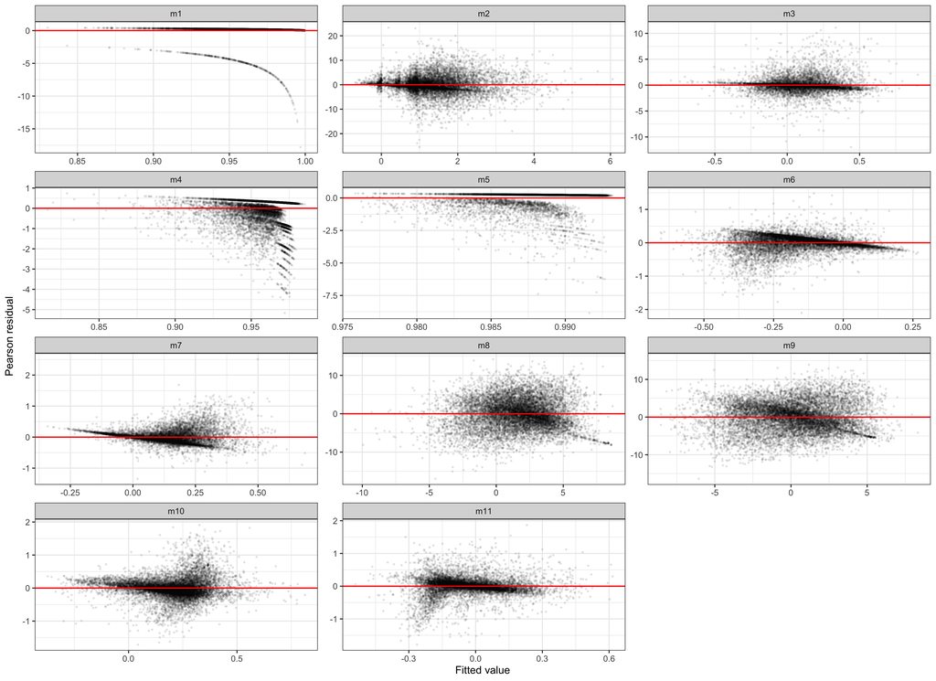

## 9.1 m1

Formula:

```
 delta_sp_32 ~ realised_C_1 * realised_S_1 + g_1 * delta_g_31 +
delta_s_21 + z_1
```

```
Call:
glm(formula = model_formulas[[id]], family = binomial(link = "logit"),
    data = data)

Deviance Residuals:
    Min       1Q   Median       3Q      Max
-3.3947   0.1720   0.2369   0.2999   0.6097

Coefficients:
                            Estimate Std. Error z value Pr(>|z|)
(Intercept)                1.3263038  0.7592107   1.747 0.080646 .
realised_C_1              -0.1477199  1.5178120  -0.097 0.922469
realised_S_1               0.0137905  0.0094220   1.464 0.143289
g_1                        0.0516643  0.0485779   1.064 0.287539
delta_g_31                 0.2239613  0.3624661   0.618 0.536653
delta_s_21                 1.2951460  0.6750597   1.919 0.055039 .
z_1                        0.0014682  0.0002306   6.366 1.94e-10 ***
realised_C_1:realised_S_1 -0.2923196  0.0786419  -3.717 0.000202 ***
g_1:delta_g_31             0.1588710  0.0680804   2.334 0.019618 *
---
Signif. codes:  0 '***' 0.001 '**' 0.01 '*' 0.05 '.' 0.1 ' ' 1

(Dispersion parameter for binomial family taken to be 1)

    Null deviance: 3174.9  on 10968  degrees of freedom
Residual deviance: 3019.2  on 10960  degrees of freedom
AIC: 3037.2

Number of Fisher Scoring iterations: 7
```

## 9.2 m2

Formula:

```
 log(delta_stabp_31) ~ realised_C_1 * realised_S_1 + g_1 * delta_g_31 +
delta_s_21 + z_1
```

```
Call:
lm(formula = model_formulas[[id]], data = data)

Residuals:
     Min       1Q   Median       3Q      Max
-25.5156  -1.4809  -0.3306   1.4118  23.3318

Coefficients:
                            Estimate Std. Error t value Pr(>|t|)
(Intercept)                6.2239239  0.5381725  11.565  < 2e-16 ***
realised_C_1               1.6978738  0.9150960   1.855 0.063566 .
realised_S_1               0.0219007  0.0056689   3.863 0.000113 ***
g_1                        0.1200170  0.0266358   4.506 6.68e-06 ***
delta_g_31                -0.8878407  0.2498271  -3.554 0.000381 ***
delta_s_21                -4.5417159  0.4968707  -9.141  < 2e-16 ***
z_1                       -0.0009494  0.0001077  -8.815  < 2e-16 ***
realised_C_1:realised_S_1 -0.2449197  0.0511673  -4.787 1.72e-06 ***
g_1:delta_g_31            -0.1183862  0.0353658  -3.347 0.000818 ***
---
Signif. codes:  0 '***' 0.001 '**' 0.01 '*' 0.05 '.' 0.1 ' ' 1

Residual standard error: 3.543 on 10598 degrees of freedom
Multiple R-squared:  0.04841,   Adjusted R-squared:  0.04769
F-statistic: 67.39 on 8 and 10598 DF,  p-value: < 2.2e-16
```

## 9.3 m3

Formula:

```
 log(delta_bmp_31) ~ realised_C_1 * realised_S_1 + g_1 * delta_g_31 +
delta_s_21 + z_1
```

```
Call:
lm(formula = model_formulas[[id]], data = data)

Residuals:
     Min       1Q   Median       3Q      Max
-11.9756  -0.3904  -0.0878   0.1506  11.1059

Coefficients:
                            Estimate Std. Error t value Pr(>|t|)
(Intercept)                1.810e-01  1.979e-01   0.915 0.360441
realised_C_1               1.156e+00  3.365e-01   3.434 0.000597 ***
realised_S_1               5.643e-04  2.087e-03   0.270 0.786815
g_1                        2.327e-02  9.792e-03   2.377 0.017489 *
delta_g_31                -4.233e-01  9.187e-02  -4.607 4.12e-06 ***
delta_s_21                 3.517e-01  1.827e-01   1.925 0.054212 .
z_1                       -9.206e-05  3.960e-05  -2.325 0.020107 *
realised_C_1:realised_S_1 -5.839e-02  1.882e-02  -3.103 0.001923 **
g_1:delta_g_31            -5.255e-02  1.300e-02  -4.041 5.35e-05 ***
---
Signif. codes:  0 '***' 0.001 '**' 0.01 '*' 0.05 '.' 0.1 ' ' 1

Residual standard error: 1.303 on 10593 degrees of freedom
Multiple R-squared:  0.01855,   Adjusted R-squared:  0.01781
F-statistic: 25.03 on 8 and 10593 DF,  p-value: < 2.2e-16
```

## 9.4 m4

Formula:

```
 delta_s_21 ~ realised_C_1 * realised_S_1 + g_1 + z_1 + stab_com_1 +
tlvl_mean_1
```

```
Family: Beta regression(1.609)
Link function: logit

Formula:
delta_s_21 ~ realised_C_1 * realised_S_1 + g_1 + z_1 + stab_com_1 +
    tlvl_mean_1

Parametric coefficients:
                            Estimate Std. Error z value Pr(>|z|)
(Intercept)                3.459e+00  8.575e-02  40.341  < 2e-16 ***
realised_C_1               2.016e+00  2.592e-01   7.777 7.45e-15 ***
realised_S_1               1.114e-03  1.644e-03   0.677  0.49816
g_1                       -3.375e-02  2.370e-03 -14.241  < 2e-16 ***
z_1                        1.095e-04  3.461e-05   3.163  0.00156 **
stab_com_1                 1.267e-02  2.479e-03   5.112 3.19e-07 ***
tlvl_mean_1               -2.133e-02  2.490e-02  -0.857  0.39171
realised_C_1:realised_S_1 -1.951e-01  1.610e-02 -12.115  < 2e-16 ***
---
Signif. codes:  0 '***' 0.001 '**' 0.01 '*' 0.05 '.' 0.1 ' ' 1


R-sq.(adj) =  0.0476   Deviance explained = -1.55%
-REML = -1.5342e+05  Scale est. = 1         n = 10969
```

## 9.5 m5

Formula:

```
 delta_s_32 ~ realised_C_1 * realised_S_1 + delta_s_21 + g_1 + z_1 +
tlvl_mean_1 + delta_sp_32 + stab_com_2
```

```
Family: Beta regression(3.837)
Link function: logit

Formula:
delta_s_32 ~ realised_C_1 * realised_S_1 + delta_s_21 + g_1 +
    z_1 + tlvl_mean_1 + delta_sp_32 + stab_com_2

Parametric coefficients:
                            Estimate Std. Error z value Pr(>|z|)
(Intercept)                4.440e+00  1.572e-01  28.246  < 2e-16 ***
realised_C_1              -1.335e-02  2.541e-01  -0.053 0.958119
realised_S_1              -9.222e-03  1.598e-03  -5.771 7.86e-09 ***
delta_s_21                 2.146e-01  1.270e-01   1.690 0.091065 .
g_1                        6.161e-03  2.313e-03   2.664 0.007718 **
z_1                       -1.253e-04  3.302e-05  -3.793 0.000149 ***
tlvl_mean_1                4.980e-05  2.442e-02   0.002 0.998373
delta_sp_32                3.043e-02  5.439e-02   0.560 0.575777
stab_com_2                 1.193e-02  2.281e-03   5.230 1.70e-07 ***
realised_C_1:realised_S_1 -6.031e-02  1.566e-02  -3.852 0.000117 ***
---
Signif. codes:  0 '***' 0.001 '**' 0.01 '*' 0.05 '.' 0.1 ' ' 1


R-sq.(adj) =  0.0363   Deviance explained = -0.24%
-REML = -2.3797e+05  Scale est. = 1         n = 10969
```

## 9.6 m6

Formula:

```
 log(delta_bmc_21) ~ realised_C_1 * realised_S_1 + g_1 + z_1 +
stab_com_1 + tlvl_mean_1
```

```
Call:
lm(formula = model_formulas[[id]], data = data)

Residuals:
     Min       1Q   Median       3Q      Max
-2.10440 -0.08519  0.03050  0.13175  1.47894

Coefficients:
                            Estimate Std. Error t value Pr(>|t|)
(Intercept)                2.956e-01  1.948e-02  15.170  < 2e-16 ***
realised_C_1              -1.863e-01  5.912e-02  -3.151  0.00163 **
realised_S_1               1.166e-03  3.724e-04   3.132  0.00174 **
g_1                       -2.026e-02  5.294e-04 -38.265  < 2e-16 ***
z_1                       -1.138e-04  7.862e-06 -14.471  < 2e-16 ***
stab_com_1                -1.457e-02  5.644e-04 -25.825  < 2e-16 ***
tlvl_mean_1               -1.028e-01  5.636e-03 -18.243  < 2e-16 ***
realised_C_1:realised_S_1  6.759e-02  3.630e-03  18.620  < 2e-16 ***
---
Signif. codes:  0 '***' 0.001 '**' 0.01 '*' 0.05 '.' 0.1 ' ' 1

Residual standard error: 0.2351 on 10961 degrees of freedom
Multiple R-squared:  0.2454,    Adjusted R-squared:  0.2449
F-statistic: 509.1 on 7 and 10961 DF,  p-value: < 2.2e-16
```

## 9.7 m7

Formula:

```
 log(delta_bmc_32) ~ realised_C_1 * realised_S_1 + delta_s_21 + g_1 +
z_1 + tlvl_mean_1 + delta_sp_32 + stab_com_2
```

```
Call:
lm(formula = model_formulas[[id]], data = data)

Residuals:
     Min       1Q   Median       3Q      Max
-1.34284 -0.12480 -0.03076  0.07787  2.51077

Coefficients:
                            Estimate Std. Error t value Pr(>|t|)
(Intercept)                3.256e-01  3.454e-02   9.425  < 2e-16 ***
realised_C_1               3.806e-01  5.589e-02   6.811 1.02e-11 ***
realised_S_1              -1.637e-03  3.508e-04  -4.667 3.09e-06 ***
delta_s_21                -5.224e-01  2.791e-02 -18.718  < 2e-16 ***
g_1                        1.777e-02  5.080e-04  34.989  < 2e-16 ***
z_1                        9.188e-05  7.252e-06  12.669  < 2e-16 ***
tlvl_mean_1                8.595e-02  5.365e-03  16.022  < 2e-16 ***
delta_sp_32                8.905e-02  1.195e-02   7.452 9.91e-14 ***
stab_com_2                 1.689e-03  5.016e-04   3.368  0.00076 ***
realised_C_1:realised_S_1 -7.511e-02  3.437e-03 -21.855  < 2e-16 ***
---
Signif. codes:  0 '***' 0.001 '**' 0.01 '*' 0.05 '.' 0.1 ' ' 1

Residual standard error: 0.2219 on 10959 degrees of freedom
Multiple R-squared:  0.2361,    Adjusted R-squared:  0.2355
F-statistic: 376.4 on 9 and 10959 DF,  p-value: < 2.2e-16
```

## 9.8 m8

Formula:

```
 log(delta_stabc_21) ~ realised_C_1 * realised_S_1 + g_1 + z_1 +
stab_com_1 + tlvl_mean_1
```

```
Call:
lm(formula = model_formulas[[id]], data = data)

Residuals:
     Min       1Q   Median       3Q      Max
-16.9453  -2.4566  -0.0581   2.4704  14.1978

Coefficients:
                            Estimate Std. Error t value Pr(>|t|)
(Intercept)               15.0696960  0.3210290  46.942  < 2e-16 ***
realised_C_1               5.6412348  0.9742157   5.791 7.21e-09 ***
realised_S_1              -0.0138951  0.0061355  -2.265   0.0235 *
g_1                       -0.0766990  0.0087234  -8.792  < 2e-16 ***
z_1                       -0.0010868  0.0001296  -8.389  < 2e-16 ***
stab_com_1                -0.5672360  0.0092991 -60.999  < 2e-16 ***
tlvl_mean_1               -1.5498226  0.0928679 -16.688  < 2e-16 ***
realised_C_1:realised_S_1 -0.6563143  0.0598165 -10.972  < 2e-16 ***
---
Signif. codes:  0 '***' 0.001 '**' 0.01 '*' 0.05 '.' 0.1 ' ' 1

Residual standard error: 3.874 on 10961 degrees of freedom
Multiple R-squared:  0.2762,    Adjusted R-squared:  0.2757
F-statistic: 597.4 on 7 and 10961 DF,  p-value: < 2.2e-16
```

## 9.9 m9

Formula:

```
 log(delta_stabc_32) ~ realised_C_1 * realised_S_1 + delta_s_21 + g_1 +
z_1 + tlvl_mean_1 + delta_sp_32 + stab_com_2
```

```
Call:
lm(formula = model_formulas[[id]], data = data)

Residuals:
     Min       1Q   Median       3Q      Max
-16.3696  -2.5764   0.0764   2.5542  15.3545

Coefficients:
                            Estimate Std. Error t value Pr(>|t|)
(Intercept)               18.0007077  0.5978007  30.112   <2e-16 ***
realised_C_1              -1.4900021  0.9670935  -1.541    0.123
realised_S_1              -0.0064243  0.0060707  -1.058    0.290
delta_s_21                -5.3125451  0.4830032 -10.999   <2e-16 ***
g_1                        0.1103430  0.0087904  12.553   <2e-16 ***
z_1                       -0.0033898  0.0001255 -27.010   <2e-16 ***
tlvl_mean_1               -1.1711224  0.0928349 -12.615   <2e-16 ***
delta_sp_32                0.0125349  0.2068073   0.061    0.952
stab_com_2                -0.5340021  0.0086805 -61.518   <2e-16 ***
realised_C_1:realised_S_1 -0.4996927  0.0594779  -8.401   <2e-16 ***
---
Signif. codes:  0 '***' 0.001 '**' 0.01 '*' 0.05 '.' 0.1 ' ' 1

Residual standard error: 3.84 on 10959 degrees of freedom
Multiple R-squared:  0.3135,    Adjusted R-squared:  0.3129
F-statistic:   556 on 9 and 10959 DF,  p-value: < 2.2e-16
```

## 9.10 m10

Formula:

```
 log(delta_ev_21) ~ realised_C_1 * realised_S_1 + g_1 + z_1 + stab_com_1
+ tlvl_mean_1
```

```
Call:
lm(formula = model_formulas[[id]], data = data)

Residuals:
     Min       1Q   Median       3Q      Max
-1.71016 -0.14764 -0.01512  0.13125  1.90873

Coefficients:
                            Estimate Std. Error t value Pr(>|t|)
(Intercept)                4.676e-01  2.566e-02  18.226  < 2e-16 ***
realised_C_1               2.105e-01  7.786e-02   2.704  0.00686 **
realised_S_1              -8.799e-05  4.903e-04  -0.179  0.85759
g_1                        2.241e-02  6.972e-04  32.151  < 2e-16 ***
z_1                       -6.192e-05  1.035e-05  -5.980 2.30e-09 ***
stab_com_1                -3.080e-03  7.432e-04  -4.145 3.42e-05 ***
tlvl_mean_1               -6.374e-02  7.422e-03  -8.588  < 2e-16 ***
realised_C_1:realised_S_1 -8.035e-02  4.780e-03 -16.808  < 2e-16 ***
---
Signif. codes:  0 '***' 0.001 '**' 0.01 '*' 0.05 '.' 0.1 ' ' 1

Residual standard error: 0.3096 on 10961 degrees of freedom
Multiple R-squared:  0.1695,    Adjusted R-squared:  0.169
F-statistic: 319.6 on 7 and 10961 DF,  p-value: < 2.2e-16
```

## 9.11 m11

Formula:

```
 log(delta_ev_32) ~ realised_C_1 * realised_S_1 + delta_s_21 + g_1 + z_1
+ tlvl_mean_1 + delta_sp_32 + stab_com_2
```

```
Call:
lm(formula = model_formulas[[id]], data = data)

Residuals:
     Min       1Q   Median       3Q      Max
-1.78219 -0.08044  0.00533  0.09671  1.86799

Coefficients:
                            Estimate Std. Error t value Pr(>|t|)
(Intercept)                1.389e+00  4.068e-02  34.158  < 2e-16 ***
realised_C_1              -3.323e-01  6.580e-02  -5.050 4.49e-07 ***
realised_S_1               9.253e-05  4.131e-04   0.224  0.82274
delta_s_21                -1.286e+00  3.286e-02 -39.121  < 2e-16 ***
g_1                       -2.015e-02  5.981e-04 -33.692  < 2e-16 ***
z_1                       -7.981e-05  8.539e-06  -9.347  < 2e-16 ***
tlvl_mean_1               -5.088e-02  6.317e-03  -8.056 8.72e-16 ***
delta_sp_32                3.643e-02  1.407e-02   2.589  0.00964 **
stab_com_2                -3.889e-03  5.906e-04  -6.584 4.80e-11 ***
realised_C_1:realised_S_1  5.525e-02  4.047e-03  13.652  < 2e-16 ***
---
Signif. codes:  0 '***' 0.001 '**' 0.01 '*' 0.05 '.' 0.1 ' ' 1

Residual standard error: 0.2613 on 10959 degrees of freedom
Multiple R-squared:  0.2083,    Adjusted R-squared:  0.2077
F-statistic: 320.5 on 9 and 10959 DF,  p-value: < 2.2e-16
```

# 10 Limitations

Scenario contrasts describe conditional associations within the simulated ensemble. Some predictor combinations and parts of the marginal-effect grids extend beyond observed combinations. Combined transition predictions are evaluated at specified covariate values rather than constrained to follow a single realised community trajectory. Their intervals quantify sampling uncertainty within the ensemble, conditional on the reference profile and model specification.

Prey-link persistence measures resource-species retention, not prey biomass or production. Its association with predator biomass does not identify the mechanism underlying this relationship. The precise historical simulation source revision associated with every input record remains unresolved.

# 11 Computational environment